# 1D Model

Anne-Karin Cooke

# Model set up

In this model, salt enters the system through rainfall and from the groundwater table with the same concentration.

## Constants

Soil properties were derived from standard Australian soils in Neurotheta (Minasny and McBratney, 2002, as cited in Shah et al, 2011).

```r
 # Sandy Clay Loam
    n<-0.367 # porosity
    # more soil variables for evaporation & losses
    # Hydraulic conductivity
    K_s<-52.08*10 # mm/day
    # campbell's b
    b<-6.4069 # neurotheta sandy clay loam
    # van Genuchten parameters
#     avg <- 0.0521
#     nvg <- 1.237
    s_fc<-0.2677/n # Field capacity
    # This is the bubbling pressure
    psi_s_bar<--1.2E-3 #

   h1bar =  -psi_s_bar
   hb = psi_s_bar*-10^5 # mm


# parameters describing the soil
  soilpar <- list(b = b, n = n, s_fc = s_fc, K_s = K_s,
                psi_s_bar = psi_s_bar, h1bar = h1bar, hb = hb)
    #................................................
    # Vegetation 1 (Grass)
    # paspalum secateum F-I and R-I, 2004

    Zr = 400 # soil depth (mm)   Check Also Table 2...Fernandez-Illescas and Rodriguez-Iturbe...2001


 # parameters describing the root zone
  vegpar <- list(Zr = Zr)


# parameters describing plant dynamics and salt features

  alpha_i=1 #maximum infiltration rate per day (K_s and therefore soil type dependency in balances function code)

  k=12 # Saco et al, 2013
  W0=0.2 # Saco et al, 2013
  gmax=0.05 # Saco et al, 2013
  k1=5 # Saco et al, 2013
  c=10  # Saco et al, 2013
  f= 1 # f is the soil salt leaching efficiency (whether some salt is retained)
  ConcConst = 0.1 # ConcConst is the concentration of the salt in the infiltrating water in g/l
  CM.gw = 0.1 # salt concentration in groundwater
  d=0.24 # fraction of plant mortality

  par <- list(alpha_i=alpha_i,k=k, W0=W0, gmax=gmax, k1=k1, c=c, f=f, ConcConst=ConcConst, CM.gw= CM.gw, d=d)
```

## Infiltration function

```r
Infil <- function(h,P, par){

  I=par$alpha_i*h*(P+par$k*par$W0)/(P+par$k)

  return (I)
}
```

## Water uptake function

```r
WU <- function(M,P,par){
# using Svir in here means scaling Svir back to M, easier to do at Svir in balances
#  WU=par$gmax*((M*(1+Svir))/(((M*(1+Svir))+par$k1)))*P
  WU=par$gmax*(M/((M+par$k1)))*P

  return(WU)
}
```

## Vertical Flux function

```r
#******************************************
# based on Salvucci, 1993
L_n <- function(M,Z,soilpar,vegpar) {
   Zr <- vegpar$Zr
   hb <- - soilpar$psi_s_bar*10^5 # (mm?)
   soilpar$s_fc <- (Z/hb)^(-1/soilpar$b)

   s=M/(soilpar$n*vegpar$Zr)

   psi = hb*s^-soilpar$b

   m=2 + 3/soilpar$b#5.64  # in Salvucci's paper it is called n, but I called it m here to not confuse it with porosity


q <-((Z/hb)^(-m)-(psi/hb)^(-m))/(1+(psi/hb)^(-m)+(m-1)*(Z/hb)^(-m))#/(soilpar$n*Zr) #

# Mass flux

flux <- soilpar$K_s*q

return(flux)
}
```

## Plant growth function

```r
Gr <- function(M,P,par) {

  Gr = par$c*WU(M,P,par)

  return(Gr)
}
```

## Plant mortality function

```r
Mo <- function(P,M,Svir,par) {
  # needs to be M/Svir because both are "large" numbers
  # you want a number ~1 for multiplication, or <0.1 for addition
  Mo = P*(par$d*(M/Svir))

  return(Mo)

}
```

## balances function

```r
balances <- function(Rain, par, plotit=T,
                      soilpar,
                      vegpar){

# Storage vectors for the daily steps are initialized.

   M <- rep(0,length(Rain)) # soil moisture [mm]
   h <- rep(0,length(Rain)) # infiltration depth [mm]
   P <- rep(0,length(Rain)) #biomass density []
   CM<- rep(0,length(Rain)) # Salt concentration in soil water in g/L or g/mm
   SmI<- rep(0,length(Rain)) # Salt mass in infiltrating water [g]
   SmM <- rep(0,length(Rain)) # Salt mass in soil water [g]
   In <- rep(0,length(Rain)) # infiltration [mm]

   Svir <- rep(0,length(Rain)) # virtual saturation
   flux<- rep(0,length(Rain)) # drainage and capillary rise flux, according to sign

# Initial values to start the simulation.


   M[1] <- 10
   h[1] <- 10
   P[1] <- 30
   CM[1]<- 0
   Svir[1] <- M[1]

# We decided to split the numerical calculations for the daily into 12 substeps.

   deltat <- 12 # split in 12 increments


# Storage vectors for the substeps are initialized.

   M_sub <- rep(0,deltat)
   h_sub <- rep(0,deltat)
   I_sub <- rep(0,deltat)
   WU_sub <-rep(0,deltat) # Water uptake in mm
   P_sub <- rep(0,deltat)
   Gr_sub <- rep(0,deltat) # Growth of biomass
   Mo_sub<- rep(0,deltat) # Mortality of biomass
   SmI_sub <- rep(0,deltat)
   SmM_sub<- rep(0,deltat)
   CM_sub<- rep(0,deltat)
  Svir_sub <- rep(0,deltat) # virtual saturation

   flux_sub<-rep(0,deltat) # calculates leakage loss without evaporation loss

   U_salt <-rep(0,deltat) # Salt mass rising
   L_salt <-rep(0,deltat) # salt mass drained



   timeincr= 1/deltat

  for (t in 2:length(Rain)){

    for (tt in 1:(deltat-1)) {

      h.old <- ifelse(tt==1,h[t-1],h_sub[tt])
      P.old <- ifelse(tt==1,P[t-1],P_sub[tt])
      M.old <- ifelse(tt==1,M[t-1],M_sub[tt])
      SmI.old <-ifelse(tt==1,SmI[t-1],SmI_sub[tt])
      CM.old <-ifelse(tt==1,CM[t-1],CM_sub[tt])
      Svir.old <-ifelse(tt==1,Svir[t-1],Svir_sub[tt])


# Balance for water depth on soil

  h_sub[tt+1] <- h.old + ifelse(tt==1,(10*Rain[t]),0)
      #- Infil(h.old, P.old,par)*timeincr

  # Infiltration
  par$alpha_i <- ifelse(h_sub[tt+1]<soilpar$K_s*timeincr, 1,(1-(h_sub[tt+1]-soilpar$K_s*timeincr)/h_sub[tt+1]))
  # Calculate infiltration and recalculate h_sub
  I_sub[tt] <- Infil(h.old, P.old,par)*timeincr
  h_sub[tt+1] <- h_sub[tt+1] - I_sub[tt]



# Now do all plant uptake and growth
# water uptake by plants: include infiltration in available water

      WU_sub[tt] <- WU(M=Svir.old,P.old,par)*timeincr

      # growth rate
      Gr_sub[tt] <- Gr(M=Svir.old, P.old,par)*timeincr
      # Mortality
      Mo_sub[tt]<- Mo(P.old,M=M.old, Svir=Svir.old, par)*timeincr
      # calculate plant biomass balance
      P_sub[tt + 1] <- P.old + Gr_sub[tt]- Mo_sub[tt]


# re-calculate water balance
# 2. before leaching
      M_sub[tt + 1] <- M.old + I_sub[tt] - WU_sub[tt] #- L_sub[tt]

# Calculate salt concentration in the soil

 # 3. calculate leaching and capillary rise amount
  flux_sub[tt+1]<-do.call(L_n,list(M=M_sub[tt+1],Z=Z,soilpar=soilpar,vegpar=vegpar))

# 4. final adjust soil moisture for leaching or capillary rise

   M_sub[tt + 1] <-  M_sub[tt + 1] + flux_sub[tt+1]*timeincr


# calculate saltbalance

# Salt leaching
    L_salt[tt+1] <- ifelse(flux_sub[tt+1]<0, par$f*CM_sub[tt+1]*flux_sub[tt+1]*timeincr,0) # leaching of salt

# salt upflow
    U_salt[tt+1] <- ifelse(flux_sub[tt+1]>0, par$CM.gw*flux_sub[tt+1]*timeincr,0) # rise of salt

# salt mass coming in with infiltration
      SmI_sub[tt+1]<- SmI.old + I_sub[tt]*par$ConcConst

#salt mass in soil
     SmM_sub[tt+1] <- SmI_sub[tt+1] + U_salt[tt+1] - L_salt[tt+1]
# salt concentration in soil
   CM_sub[tt+1]<- (SmM_sub[tt+1]/M_sub[tt+1])*(1/58.44) #

# Virtual saturation (Shah et al., 2012), here in [mm] to be in the same unit as M
    Svir_sub[tt + 1]<-soilpar$n*vegpar$Zr*((soilpar$h1bar*10^-1)^(1/soilpar$b))*
                     ((soilpar$h1bar*10^-1)*(M_sub[tt + 1]/
                       (soilpar$n*vegpar$Zr))^(-soilpar$b)
                       +(3.6*CM_sub[tt + 1]))^(-1/soilpar$b)

    }

# Aggregating the substep results to daily values.

    P[t] = P_sub[deltat]
    M[t] = M_sub[deltat]
    h[t] = h_sub[deltat]
    CM[t] = CM_sub[deltat]
    SmM[t] = SmM_sub[deltat]
    SmI[t]=SmI_sub[deltat]
    In[t]= sum(I_sub)
    flux[t] = sum(flux_sub)
    Svir[t] = Svir_sub[deltat]

}


# Plotting

if (plotit==T) {
  plot(Rain*10, type="h",col="skyblue",ylim=c(0,100),xlim=c(0,time),xlab=("time [d]"), ylab=("[mm]"))
  lines(M, type="l",col="black" )

    lines(h,type="l", col="blue")
    abline(h=0, col="Gray50",lwd=2,lty=2)

    lines(SmM,type="l", col="red")
    lines(CM*100,type="l", col="purple")
    lines(P/10,type="l", col="green")
    lines(flux,type="l", col="orange")


 legend("topright", title="Variables",cex=0.5, pt.cex=0.1, c("Moisture [mm]","Rainfall [mm]*10","overland flow depth[mm] ","salt mass in soil water [g]", "salt concentration in soil water [g/l]*100", "Plant biomass density [g/m^2]/10", "Vertical water flux [mm]"),
         col=c("black","skyblue","blue","red","purple","green", "orange"),lty=1)

}

Out <- data.frame(P=P,M=M,h=h, CM=CM, SmM=SmM, In=In, flux=flux, Svir=Svir)
#return(Out)
}
```

## Uniform rain of 1 mm per day

```r
    Rain_function<-function(time){ Rain <- rep(1, time)
                         return(Rain)}
```

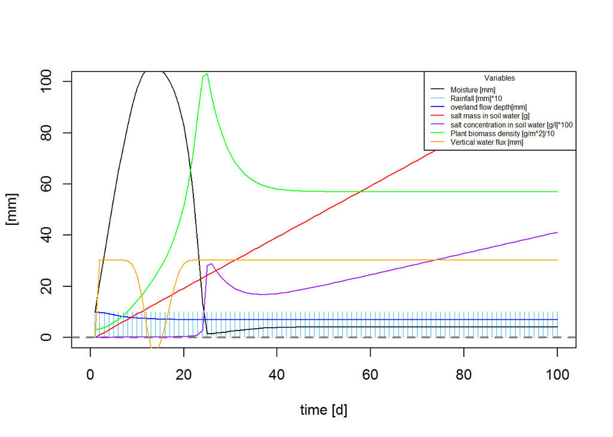

```r
    Z =1000 # [mm]  groundwater depth
    time = 100 #days
    balances(Rain=Rain_function(time), par=par, plotit=T, soilpar, vegpar)
```

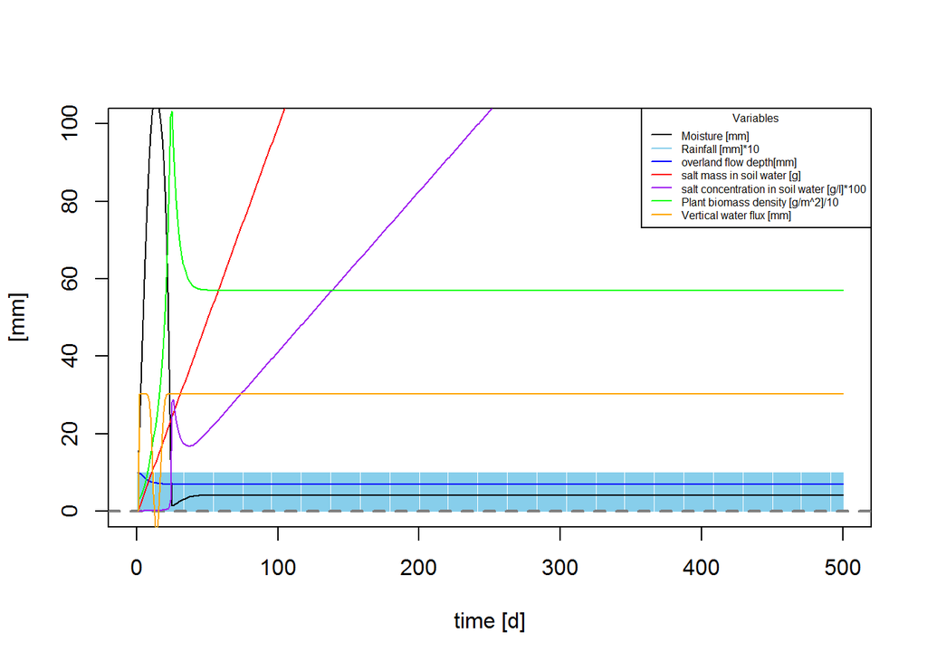

```r
    time =500
    balances(Rain=Rain_function(time), par=par, plotit=T, soilpar, vegpar)
#     Z =2000 # [mm]  groundwater depth
#     time = 100 #days
#     balances(Rain=Rain_function(time), par=par, plotit=T, soilpar, vegpar)
#     time =500 #days
#     balances(Rain=Rain_function(time), par=par, plotit=T, soilpar, vegpar)
#     Z =3000 # [mm]  groundwater depth
#     time = 100 #days
#     balances(Rain=Rain_function(time), par=par, plotit=T, soilpar, vegpar)
#     time =500 #days
    balances(Rain=Rain_function(time), par=par, plotit=T, soilpar, vegpar)
```

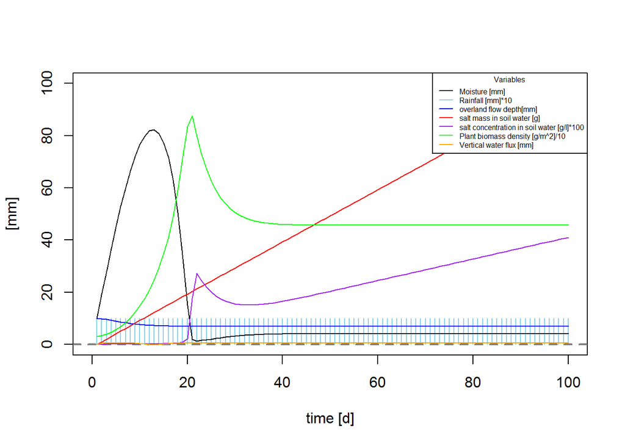

```r
    Z =5000 # [mm]  groundwater depth
    time = 100 #days
    balances(Rain=Rain_function(time), par=par, plotit=T, soilpar, vegpar)
```

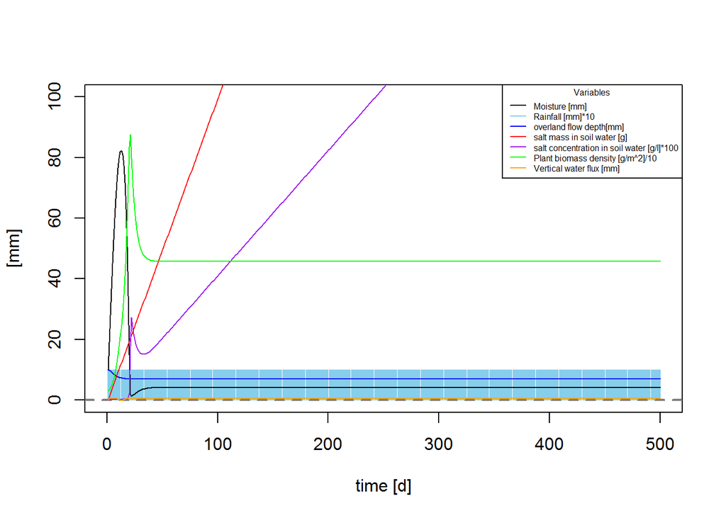

```r
    time =500 #days
    balances(Rain=Rain_function(time), par=par, plotit=T, soilpar, vegpar)
```

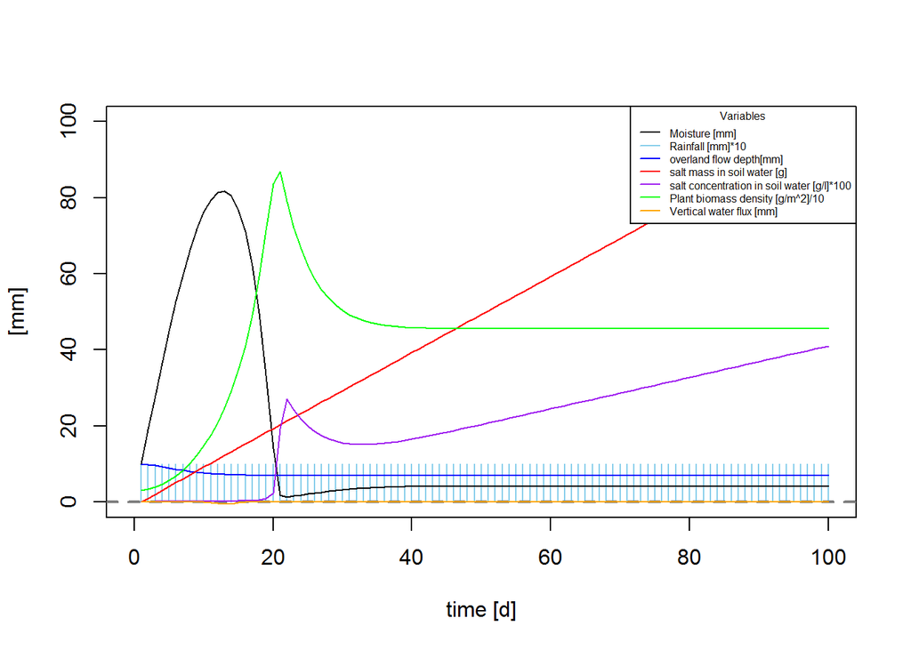

```r
    Z =10000 # [mm]  groundwater depth
    time = 100 #days
    balances(Rain=Rain_function(time), par=par, plotit=T, soilpar, vegpar)
```

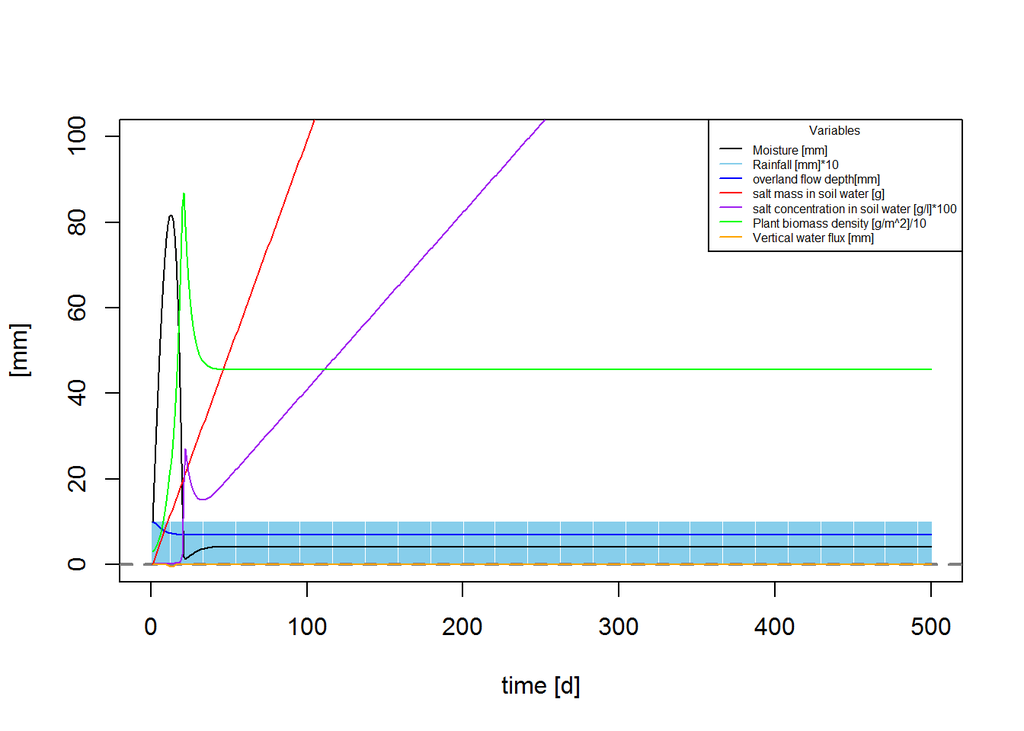

```r
    time =500 #days
    balances(Rain=Rain_function(time), par=par, plotit=T, soilpar, vegpar)
```

## Discussion - changing Z (distance to groundwater depth)

After some flucations at the beginning which can be considered the initalization of the model, soil moisture, plant biomass and overland flow depths stabilize on the longterm. Whereas salt mass and concentrations continously rise as they are brought in by infiltration with every rainfall and accumulate in the soil. Plant biomass will eventually die, as soon as salt concentration make the soil inhabitable. The shallower the water table, the more water enters the soil moisture storage through capillary rise (“flux” in the graphs is much higher) and can be used by plants. Therefore plant biomass stabilizes at a higher level, the closer the groundwater table.

## Testing different soil types

### Medium Heavy Clay

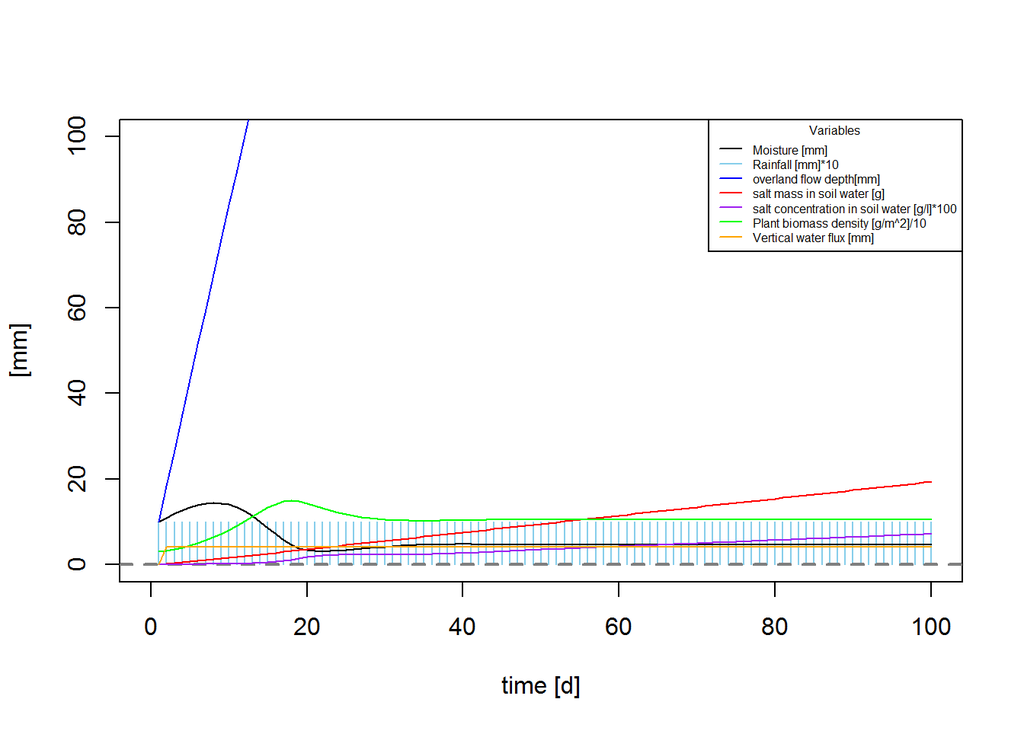

```r
  # Medium Heavy Clay
    n<-0.4473 # porosity
    # more soil variables for evaporation & losses
    # Hydraulic conductivity
    K_s<-2.82*10 # mm/day
    # Campbell's b
    b<-16.1501 # neurotheta Medium heavy clay

    s_fc<-0.3936/n # Field capacity
    # bubbling pressure
    psi_s_bar<--1.4E-3
    h1bar =  -psi_s_bar
    hb = psi_s_bar*-10^5 #mm


# parameters describing the soil
  soilpar <- list(b = b, n = n, s_fc = s_fc, K_s = K_s,
                psi_s_bar = psi_s_bar, h1bar = h1bar, hb = hb)

    Z =1000 # [mm]  groundwater depth
    time = 100 #days
    balances(Rain=Rain_function(time), par=par, plotit=T, soilpar, vegpar)
```

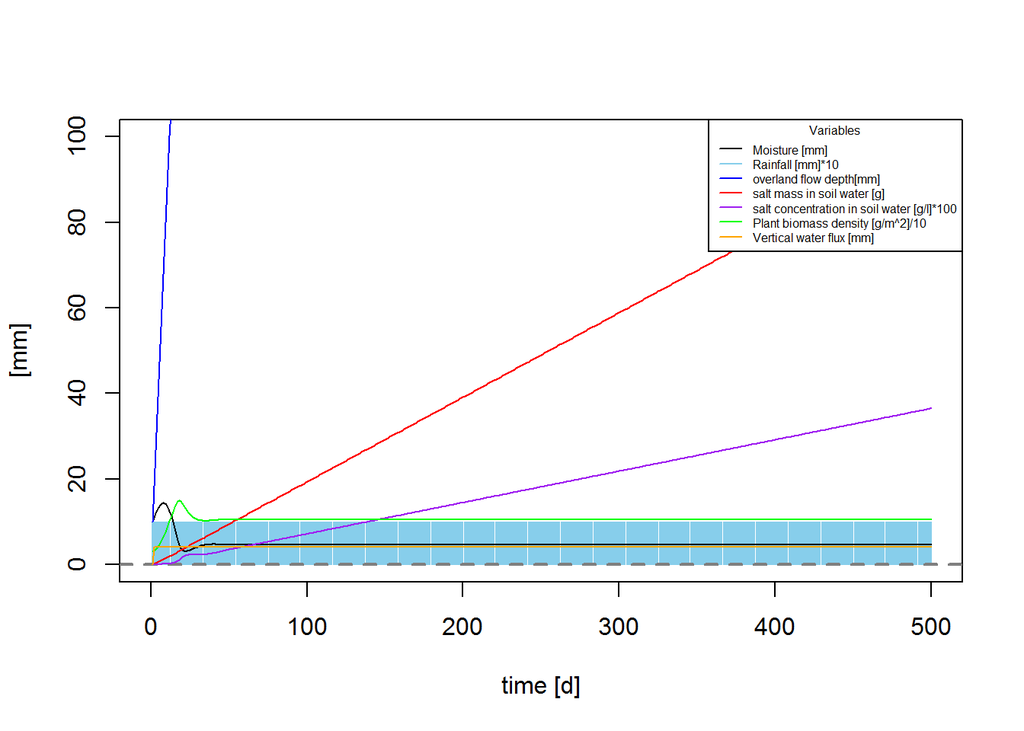

```r
    time =500
    balances(Rain=Rain_function(time), par=par, plotit=T, soilpar, vegpar)
```

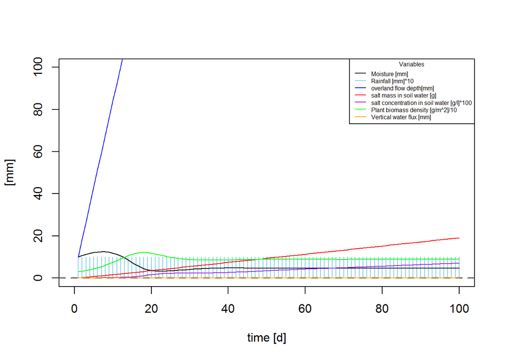

```r
    Z =10000 # [mm]  groundwater depth
    time = 100 #days
    balances(Rain=Rain_function(time), par=par, plotit=T, soilpar, vegpar)
```

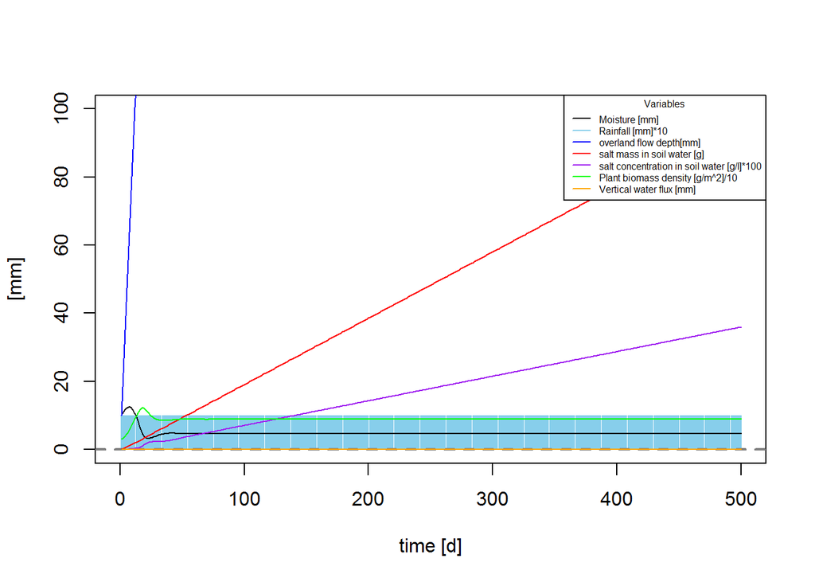

```r
    time =500
    balances(Rain=Rain_function(time), par=par, plotit=T, soilpar, vegpar)
```

## Testing different soils

### Coarse Sand

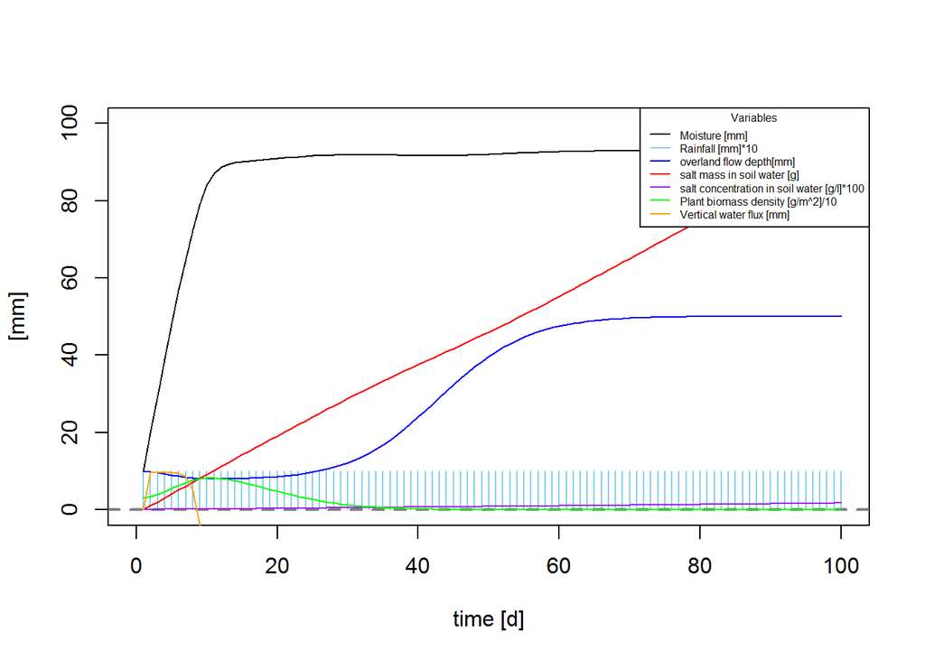

```r
# Coarse Sand
    n<-0.368 # porosity
    # more soil variables for evaporation & losses
    # Hydraulic conductivity
    K_s<-182.68*10 # mm/day
    # Campbell's b
    b<- 4.1152

    s_fc<-0.1895/n # Field capacity

    psi_s_bar<--0.61E-3
   h1bar =  -psi_s_bar
   hb = psi_s_bar*-10^5 #mm

# parameters describing the soil
  soilpar <- list(b = b, n = n, s_fc = s_fc, K_s = K_s,
                psi_s_bar = psi_s_bar, h1bar = h1bar, hb = hb)

    Z =1000 # [mm]  groundwater depth
    time = 100 #days
    balances(Rain=Rain_function(time), par=par, plotit=T, soilpar, vegpar)
```

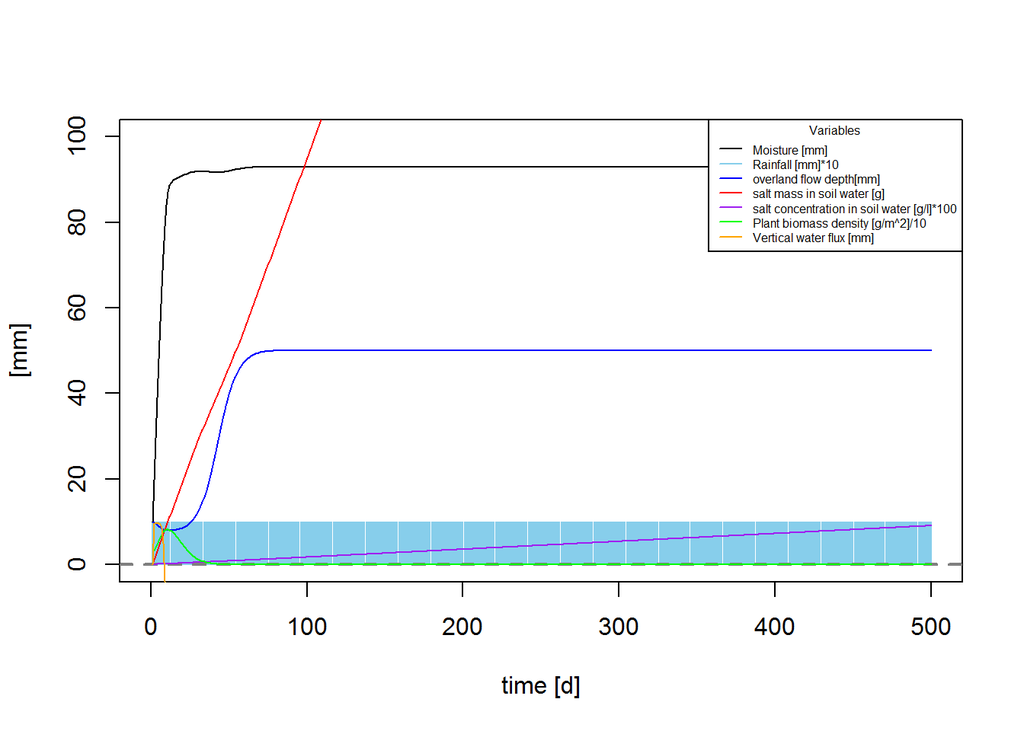

```r
    time =500
    balances(Rain=Rain_function(time), par=par, plotit=T, soilpar, vegpar)
```

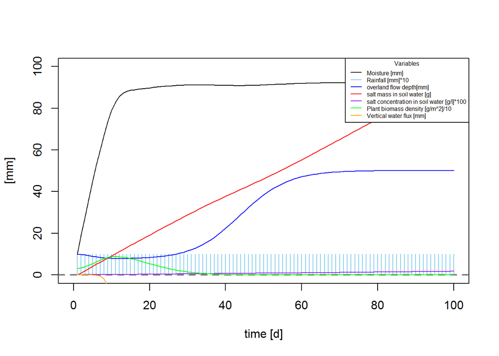

```r
    Z =10000 # [mm]  groundwater depth
    time = 100 #days
    balances(Rain=Rain_function(time), par=par, plotit=T, soilpar, vegpar)
```

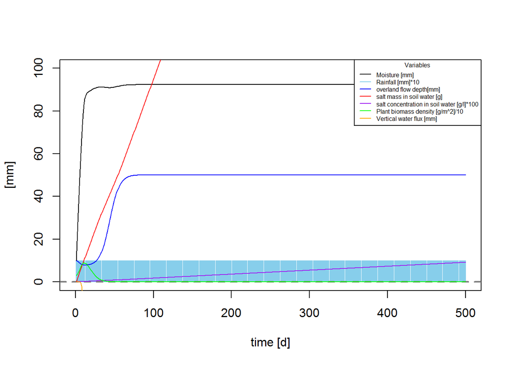

```r
    time =500
    balances(Rain=Rain_function(time), par=par, plotit=T, soilpar, vegpar)
```